# Multidimensional Scaling

Aravind

Monday, June 06, 2016

clustering is a key component within R, that allows you to group similar sets of objects together. classical multidimensional scaling using cmdscale in R using cmdscale function, using this function we can understant the similarities and disimilarites between records based on a measure of distance or metric between them — for this example we use the eurodist dataset to understant the cmdscale function.. —

```r
summary(eurodist)
```

```
##    Min. 1st Qu.  Median    Mean 3rd Qu.    Max.
##     158     808    1312    1505    2064    4532
```

There are 21 major europion cities in this dataset..

```r
as.matrix(eurodist)[1:5, 1:5]
```

```
##           Athens Barcelona Brussels Calais Cherbourg
## Athens         0      3313     2963   3175      3339
## Barcelona   3313         0     1318   1326      1294
## Brussels    2963      1318        0    204       583
## Calais      3175      1326      204      0       460
## Cherbourg   3339      1294      583    460         0
```

The above subset lists (first 5-5 values) of the distance matrix represents the travel distance between 21 European cities in kilometers

Let us call cmdscale function on eurodist (remember distance is already caluclated in metrix..)

```r
msd<- cmdscale(eurodist)
msd
```

```
##                         [,1]        [,2]
## Athens           2290.274680  1798.80293
## Barcelona        -825.382790   546.81148
## Brussels           59.183341  -367.08135
## Calais            -82.845973  -429.91466
## Cherbourg        -352.499435  -290.90843
## Cologne           293.689633  -405.31194
## Copenhagen        681.931545 -1108.64478
## Geneva             -9.423364   240.40600
## Gibraltar       -2048.449113   642.45854
## Hamburg           561.108970  -773.36929
## Hook of Holland   164.921799  -549.36704
## Lisbon          -1935.040811    49.12514
## Lyons            -226.423236   187.08779
## Madrid          -1423.353697   305.87513
## Marseilles       -299.498710   388.80726
## Milan             260.878046   416.67381
## Munich            587.675679    81.18224
## Paris            -156.836257  -211.13911
## Rome              709.413282  1109.36665
## Stockholm         839.445911 -1836.79055
## Vienna            911.230500   205.93020
```

cmdscale transformed the 21-dimensional metrix into 2 dimensions, now we can use plot function to plot easily..

Let us plot the 2 dimension metrix..

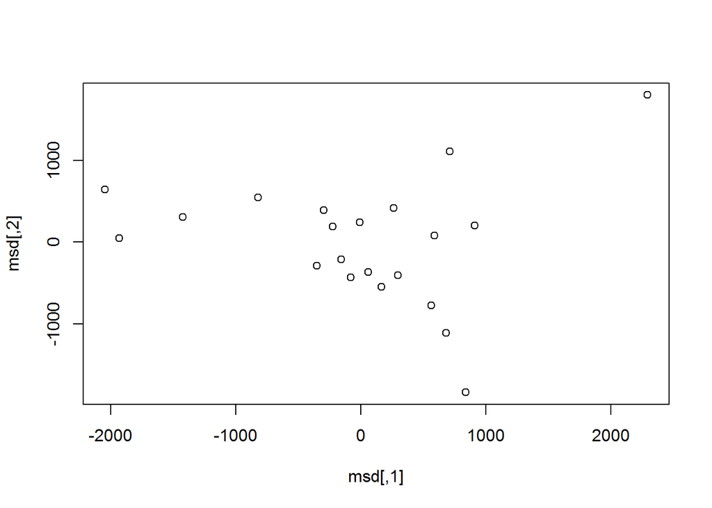

```r
plot(msd)
```

so as you can see in the plot, you will notice near the center is where most of the cities are clustred.. which is the mail center of the major european cities… and as we move cites go forther away.. on the top right side is the athens..

graph is not much usefull with out labels lets plot with the labels..

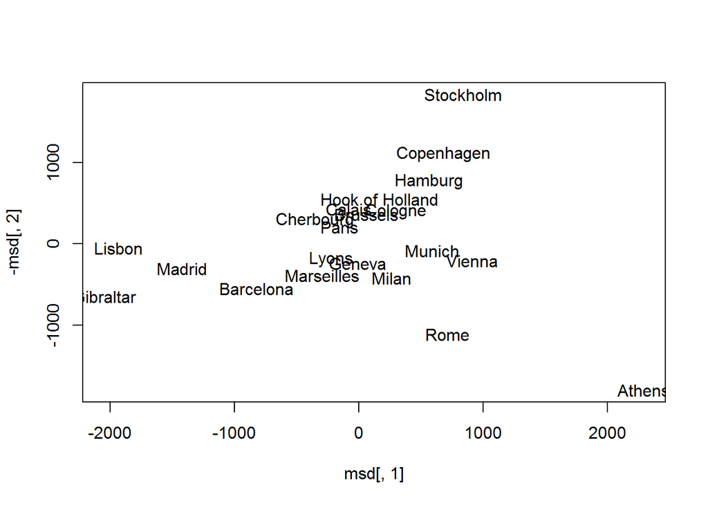

```r
plot(msd[,1],-msd[,2],type="n")
text(msd[,1],-msd[,2],rownames(msd))
```

-msd[,2] is to flipp the Y axis

now let us see how to apply MDS on non-geographic data, which was not prepared to be a distance matrix.. and plot the results for this we use the mtcars dataset

```r
summary(mtcars)
```

```
##       mpg             cyl             disp             hp
##  Min.   :10.40   Min.   :4.000   Min.   : 71.1   Min.   : 52.0
##  1st Qu.:15.43   1st Qu.:4.000   1st Qu.:120.8   1st Qu.: 96.5
##  Median :19.20   Median :6.000   Median :196.3   Median :123.0
##  Mean   :20.09   Mean   :6.188   Mean   :230.7   Mean   :146.7
##  3rd Qu.:22.80   3rd Qu.:8.000   3rd Qu.:326.0   3rd Qu.:180.0
##  Max.   :33.90   Max.   :8.000   Max.   :472.0   Max.   :335.0
##       drat             wt             qsec             vs
##  Min.   :2.760   Min.   :1.513   Min.   :14.50   Min.   :0.0000
##  1st Qu.:3.080   1st Qu.:2.581   1st Qu.:16.89   1st Qu.:0.0000
##  Median :3.695   Median :3.325   Median :17.71   Median :0.0000
##  Mean   :3.597   Mean   :3.217   Mean   :17.85   Mean   :0.4375
##  3rd Qu.:3.920   3rd Qu.:3.610   3rd Qu.:18.90   3rd Qu.:1.0000
##  Max.   :4.930   Max.   :5.424   Max.   :22.90   Max.   :1.0000
##        am              gear            carb
##  Min.   :0.0000   Min.   :3.000   Min.   :1.000
##  1st Qu.:0.0000   1st Qu.:3.000   1st Qu.:2.000
##  Median :0.0000   Median :4.000   Median :2.000
##  Mean   :0.4062   Mean   :3.688   Mean   :2.812
##  3rd Qu.:1.0000   3rd Qu.:4.000   3rd Qu.:4.000
##  Max.   :1.0000   Max.   :5.000   Max.   :8.000
```

```r
head(mtcars)
```

```
##                    mpg cyl disp  hp drat    wt  qsec vs am gear carb
## Mazda RX4         21.0   6  160 110 3.90 2.620 16.46  0  1    4    4
## Mazda RX4 Wag     21.0   6  160 110 3.90 2.875 17.02  0  1    4    4
## Datsun 710        22.8   4  108  93 3.85 2.320 18.61  1  1    4    1
## Hornet 4 Drive    21.4   6  258 110 3.08 3.215 19.44  1  0    3    1
## Hornet Sportabout 18.7   8  360 175 3.15 3.440 17.02  0  0    3    2
## Valiant           18.1   6  225 105 2.76 3.460 20.22  1  0    3    1
```

before we call the cmdscale function we need to call the dist function to calculate the distance then we can call the cmdscale function, and plot the results with no axis elements

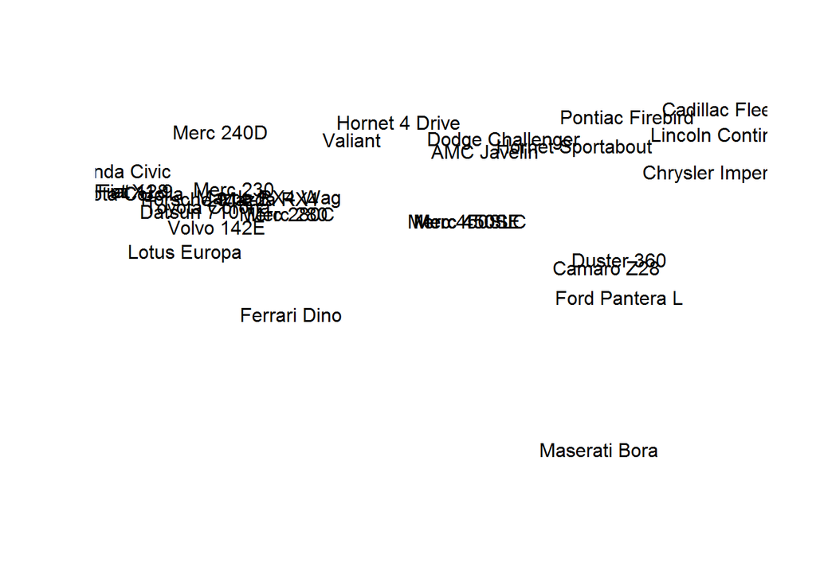

```r
mds <- cmdscale(dist(mtcars))
plot(mds, type = 'n', axes = FALSE, xlab = '', ylab = '')
text(mds[, 1], mds[, 2], rownames(mds))
```

The distance between the elements was computed by MDS, which took into account all the 11 original numeric variables, and it makes vert easy to identify the similar and very different car types